# Visualización de datos en R

joseangeldiazg

November 22, 2017

# Ejercicio 1:

### Plot distance against stretch.

Vamos a crear el dataframe con los datos de prueba:

```r
strech<-c(46,54,48,50,44,42,52)
distance<-c(148,182,173,166,109,141,166)
data<-data.frame(strech,distance)
```

Visualizamos los datos creados:

```r
data
```

```
##   strech distance
## 1     46      148
## 2     54      182
## 3     48      173
## 4     50      166
## 5     44      109
## 6     42      141
## 7     52      166
```

Creamos el gráfico

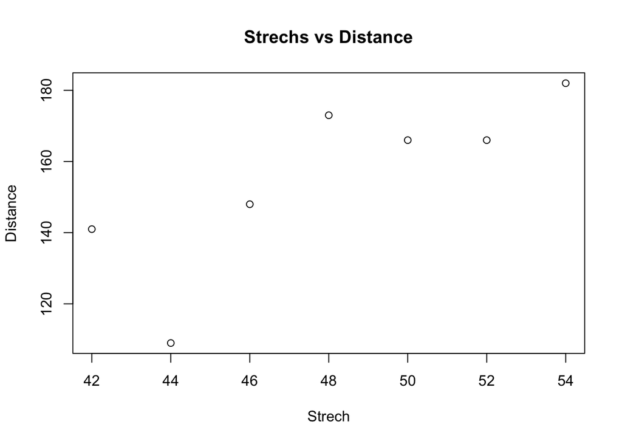

```r
plot(data$strech, data$distance, main="Strechs vs Distance", xlab="Strech", ylab="Distance")
```

# Ejercicio 2:

### The table on the right have ten observations, taken during the years 1970-79, are on October snow cover for Eurasia (snow cover is in millions of square kilometers):

- Plot snow.cover versus year:
- Plot a histogram of the snow.cover values:

Vamos a crear los datos, para ello procedemos como antes creando dos vectores y uniéndolos en un dataframe.

```r
year<-c(1970,1971,1972,1973,1974,1975,1976,1977,1978,1979)
snow.cover<-c(6.5,12.0,14.9,10.0,10.7,7.9,21.9,12.5,14.5,9.2)
year.snow<-data.frame(year, snow.cover)
```

Mostramos el dataframe creado para ver si tenemos los daos como deseamos.

```r
year.snow
```

```
##    year snow.cover
## 1  1970        6.5
## 2  1971       12.0
## 3  1972       14.9
## 4  1973       10.0
## 5  1974       10.7
## 6  1975        7.9
## 7  1976       21.9
## 8  1977       12.5
## 9  1978       14.5
## 10 1979        9.2
```

Pintamos el gráfico de **snow.cover** vs **year**, con lo que tendríamos hecho el primer apartado:

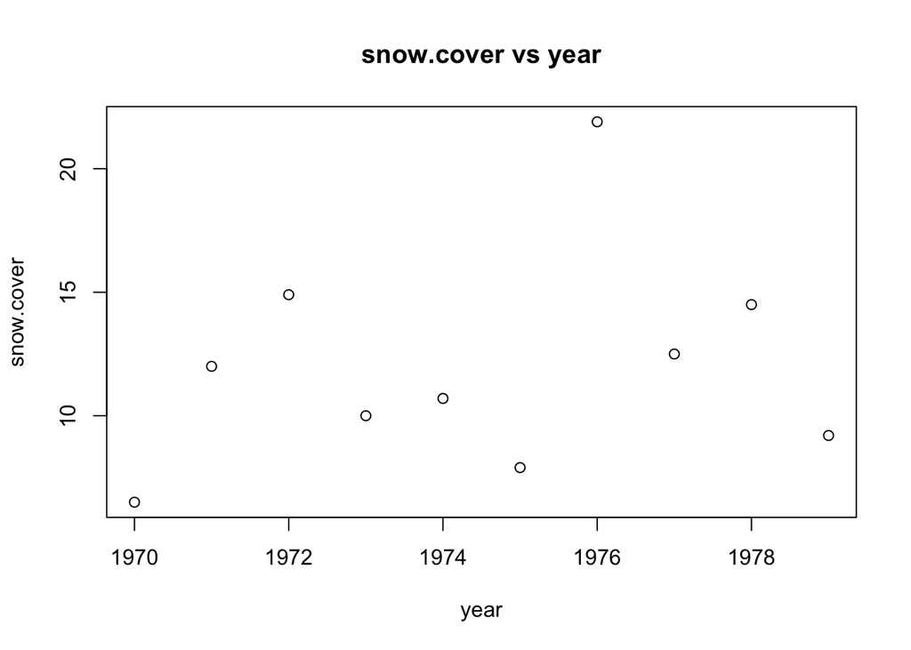

```r
plot( year.snow$year,year.snow$snow.cover, main="snow.cover vs year", xlab="year", ylab="snow.cover" )
```

El siguiente punto pasa por la elaboración de un histograma, para ello podemos usar **hist()**

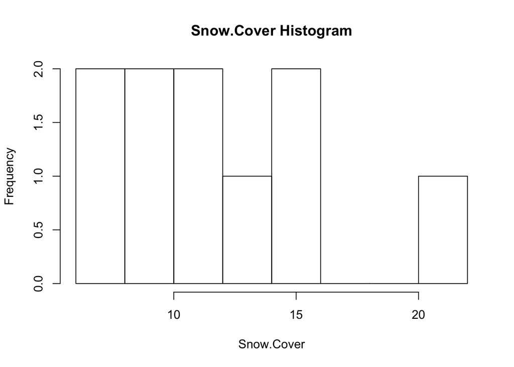

```r
hist(snow.cover, main="Snow.Cover Histogram", xlab="Snow.Cover", breaks=10)
```

Vamos a probar con menos cortes:

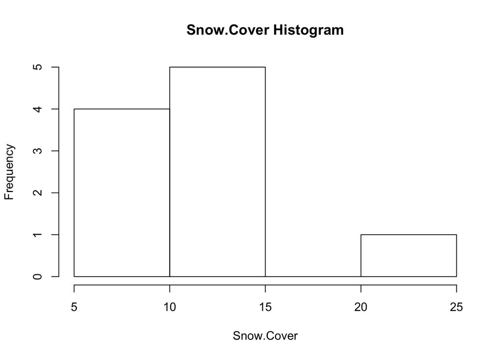

```r
hist(snow.cover, main="Snow.Cover Histogram", xlab="Snow.Cover", breaks=5)
```

A mi juicio este nos ofrece mejores resultados ya que podemos ver que no hay ninguno entre 15 y 20, que el minimo está por encima de 5, y el máximo es <= que 25, ademas como que la mayor parte de los años el Snow.Cover ha estado situado entre 10 y 15.

# Ejercício 3

### Given the data in NY.xls

- (Optional)conver to F to oC and in to mm.
- PlotYear vs Warmest Minimum Temperature
- PlotYear vs Warmest Minimum Temperature and Coldest Minimum Temperature. Don’t forget to add a legend!

El primer paso es cargar los datos para ello:

```r
library(readxl)
NY <- read_excel("datasets/NY.xls")
View(NY)
```

El primer paso es convertir F a Grados e in a mm, para ello primero creamos dos funciones que realizan lo deseado:

```r
ftoc<-function(gradosf)
{
  return ((gradosf-32)*(5/9))
}

intomm<-function(invalue)
{
  return (as.numeric(invalue)*25.4)
}
```

Ahora usamos la función para cada columna que queremos cambiar:

```r
NY[2:8]<-apply(NY[2:8],2,ftoc)
```

Y por último cambiamos los elementos en in por mm:

```r
NY[9:12]<-apply(NY[9:12],2,intomm)
ny.dataframe<-data.frame(NY)
```

Ahora pintamos el gráfico como hemos hecho en puntos anteriores:

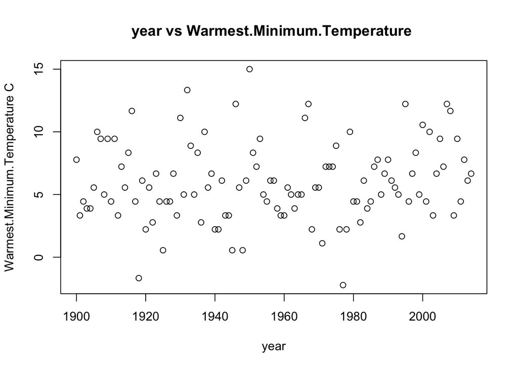

```r
plot(ny.dataframe$Year, ny.dataframe$Warmest.Minimum.Temperature..F. , main="year vs Warmest.Minimum.Temperature ", xlab="year", ylab="Warmest.Minimum.Temperature C" )
```